# Martian Alphabet

2022-03-10

## Learning outcomes

- Carry out the statistical investigation process.
- Program a simulation-based hypothesis test.

## Can you read “Martian”?

How well can humans distinguish one “Martian” letter from another? In today’s activity, we’ll find out. When shown the two Martian letters, Kiki and Bumba, write down whether you think Bumba is on the left or on the right.

1. Were you correct or incorrect in identifying Bumba?

### Steps of the statistical investigation process

#### Step 1:

The first step of any statistical investigation is to *ask a research question*. In this study the research question is: Can we as a class read Martian? (We will refine this later on!).

#### Step 2:

To answer any research question, we must *design a study and collect data*. For our question, the study consists of each student being presented with two Martian letters and asking which was Bumba. Your responses will become our observed data that we will explore.

**Observational units** or **cases** are the subjects data are collected on. In a spreadsheet of the data set, each row represents a single observational unit.

2. What are the observational units in this study?
- One observational unit = one student
3. How many students are in class today? This is the **sample size**.

$n$ = 13

A **variable** is information collected or measured on each observational unit or case. Each column in a data set will represent a different variable. Today we are only measuring one variable on each observational unit.

4. **Identify the variable we are collecting on each observational unit in this study, i.e., what are we measuring on each student?** *Hint*: Your answer to question 1 is the outcome for the variable measured on one observational unit.
- If student is correct or incorrect in their guess.
5. Is the variable identified in question 4 categorical or quantitative?
- Categorical (binary)

#### Step 3:

Once we have collected data, the next step is to *summarize and visualize the data*.

6. How many people in your class were correct in identifying Bumba? Using the class size from question 3, calculate the proportion of students who correctly identified Bumba.

```r
prop <- 9/13
prop
```

```
## [1] 0.6923077
```

The proportion in question 6 is called a **summary statistic**—a single value that summarizes the data set. It is important to note that a variable is different than a summary statistic. A *variable* is measured on a *single observational unit* while a summary statistic is calculated from a group of observational units. For example, the variable “whether or not a student lives on campus” can be measured on each individual student. In a class of 50 students we can calculate the proportion of students who live on campus, the summary statistic. Look back and make sure you wrote the variable in question 4 as a variable, NOT a summary statistic.

Looking at the data set and the summary statistic is only one way to display the data. We will also want to create a visualization or picture of the data.

7. Create a well-labeled plot of the observed class data.

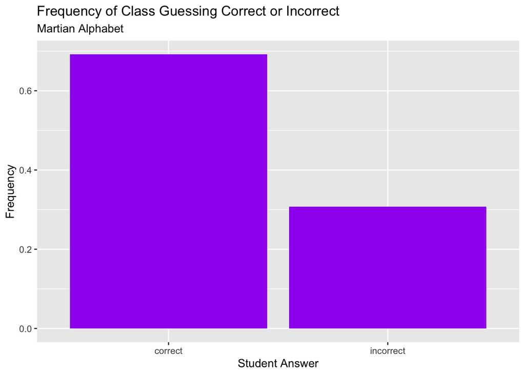

```r
martian <- data.frame(
  outcome = rep( c("correct", "incorrect"), c(9, 4) )
)
ggplot(data = martian, aes(x = outcome)) +
  geom_bar(aes(y = ..prop.., group = 1), fill = "purple") +
  labs(x = "Student Answer", y = "Frequency",
       title = "Frequency of Class Guessing Correct or Incorrect",
       subtitle = "Martian Alphabet")
```

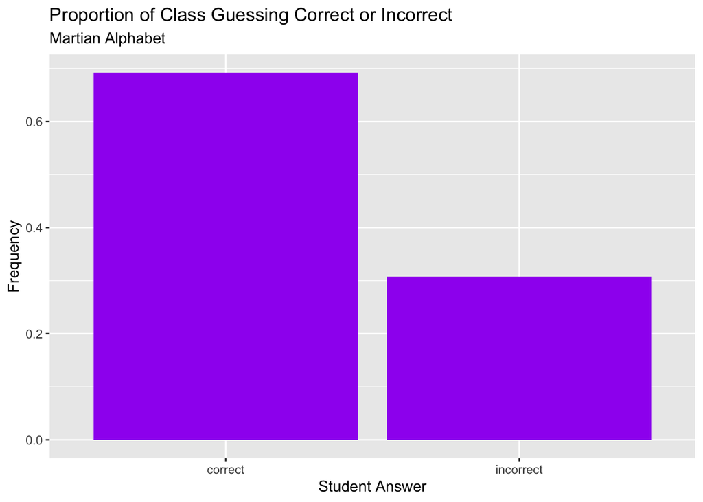

```r
martian_sum <- data.frame(
  outcome = c("correct", "incorrect"),
  proportion = c(9/13, 4/13)
)

ggplot(data = martian_sum, aes(x = outcome, y = proportion)) +
  geom_col(fill = "purple") +
  labs(x = "Student Answer", y = "Frequency",
       title = "Proportion of Class Guessing Correct or Incorrect",
       subtitle = "Martian Alphabet")
```

#### Step 4:

The next step is to *use statistical analysis methods to draw **inferences** from the data*. To answer the research question, we will simulate what *could* have happened in our class given random chance, repeat many times to understand the expected *variability* between different “randomly guessing” classes, then compare our class’s observed data to the simulation. This gives us an estimate of how often (or the probability of) the class’s result would occur if students were all merely guessing, allowing us to determine if the data provide evidence that we as a class can read Martian.

8. If humans really don’t know Martian and are just guessing which is Bumba, what are the chances of getting it right?
- 0.50 (50%)
9. Use R to simulate one student’s “guess” under the assumption that we can’t read Martian. What was the result of your one simulation?

```r
sample(c("correct", "incorrect"), size = 1, prob = c(0.5, 0.5))
```

```
## [1] "incorrect"
```

10. How could we use coins to simulate the entire class “just guessing” which Martian letter is Bumba?
- We would need 13 coins
11. How many people in your class would you expect to choose Bumba correctly just by chance? Explain your reasoning.

```r
13*.5
```

```
## [1] 6.5
```

12. Now use R to simulate an entire class just guessing. What was the result from your class’s simulation?  
    What proportion of students “guessed” correctly in the simulation?

```r
x <- sample(c("correct", "incorrect"), size = 13, prob = c(0.5, 0.5), replace = TRUE)

data.frame(x) %>% group_by(x) %>% count()
```

```
## # A tibble: 2 × 2
## # Groups:   x [2]
##   x             n
##   <chr>     <int>
## 1 correct       5
## 2 incorrect     8
```

```r
mean(ifelse(x == "correct", 1, 0))
```

```
## [1] 0.3846154
```

```r
mean(x == "correct")
```

```
## [1] 0.3846154
```

13. If students really don’t know Martian and are just guessing which is Bumba, which seems more unusual: the result from your class’s **simulation** in question 12 or the observed proportion of students in your class that were correct (this is your summary statistic from question 6)?  
    Explain your reasoning.
14. While your observed class data is likely far different from the simulated “just-guessing” class, comparing our class data to a single simulation does not provide enough information. The differences seen could just be due to the randomness of that set of coin flips! Let’s simulate another class. Run your code from question 12 again. What was the result from your class’s second simulation? What proportion of students “guessed” correctly in the second simulation? Create a plot to compare the two simulated results with the observed class result.
15. **We still only have a couple of simulations to compare our class data to. It would be much better to be able to see how our class compared to hundreds or thousands of “just-guessing” classes. Use a for loop in R to simulate 1,000 “just-guessing” classes and keep track of the proportion of each class that guessed correctly.

```r
sim_props <- vector("numeric", 1000)

sim_props <- NULL

for(i in 1:1000){
  x <- sample(c("correct", "incorrect"),
              size = 13, prob = c(0.5, 0.5), replace = TRUE)
  sim_props[i] <- mean(x == "correct")
}
```

14. Create a plot of the distribution of simulated proportions from question 13. **What does one “dot” on the plot represent in context of the problem?**

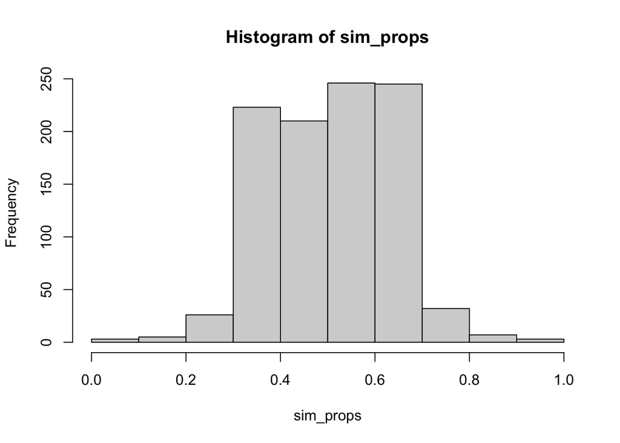

```r
hist(sim_props)
```

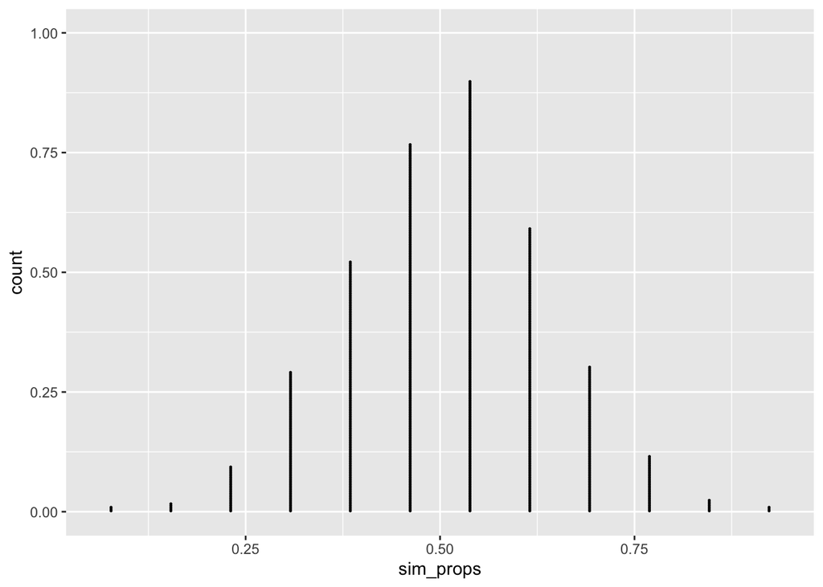

```r
data.frame(sim_props) %>% ggplot(aes(x = sim_props)) +
  geom_dotplot(dotsize = 0.08)
```

15. Based on your plot in question 14, is your class particularly good or bad at Martian? Explain.
16. Is it *possible* that we could see our class results just by chance if everyone was just guessing? Explain your reasoning.
17. **Is it *likely* that we could see our class results just by chance if everyone was just guessing? Explain your reasoning.**

A **p-value** is the probability of seeing the result in your data, or something “more extreme”, under the assumption of a null hypothesis. A null hypothesis is usually one of “no effect” or “just by chance” — an assumption under which it is relatively is easy to simulate data.

18. In this activity, describe in context the following statistical terms:
- **null hypothesis** ($H_0$) - The class can’t read Martian. OR The class is just guessing. OR The true probability of choosing the correct answer is 0.5.
- **alternative hypothesis** ($H_a$) - The class can read Martian. OR The class is NOT just guessing. OR The true probability of choosing the correct answer is greater than 0.5.
- **p-value** - The probability of getting a proportion guessing correctly of 0.6923077 or greater, assuming the true proportion of guessing correctly is equal to 0.5.

19. Use your results from question 13 to estimate the p-value for this analysis.
20. Write a function in R that will calculate an estimated p-value for this situation, where the function takes inputs: observed data, desired number of simulations.

```r
p_value <- function(x, n, reps = 1000){
  # x = number of correct guesses in observed data
  # n = sample size
  # reps = number of simulated classes
  sim_props <- NULL
  for(i in 1:reps){
    my_samp <- sample(c("correct", "incorrect"),
                      size = n, prob = c(0.5, 0.5), replace = TRUE)
    sim_props[i] <- mean(my_samp == "correct")
  }
  return( mean(sim_props >= x/n) )
}

p_value(9, 13, reps = 10000)
```

```
## [1] 0.133
```

21. In STAT 216, we use the R package `catstats` to conduct these simulation-based hypothesis tests. In question 20, you wrote a function similar to the `one_proportion_test()` function in `catstats`. This function can be found in the code [here](https://github.com/greenwood-stat/catstats/blob/master/R/s216-applets.R). Find the `one_proportion_test()` function in the code and compare it to your function. What does `one_proportion_test()` include that yours does not?

#### Step 5:

The next step in the statistical investigation process is to *communicate the results and answer the research question*.

22. Does this activity provide strong evidence that students were not just guessing at random? If so, what do you think is going on here? Can we as a class read Martian?[^1]
[^1]: Reference for “Martian alphabet” is a TED talk given by Vilayanur Ramachandran in 2007. The synesthesia part begins at roughly 17:30 minutes: `http://www.ted.com/talks/vilayanur_ramachandran_on_your_mind`.